# Visualisasi data Numerik

## LINE CHART

Plot ini digunakan untuk melihat trend data berdasarkan perubahan waktu. Artinya pada **Line Chart** cocok untuk data-data deret waktu.

### Input Data

Data yang digunakan yaitu data Pasar Saham Amerika Serikat dan Indikator Teknisnya.Adapun dataset ini bersumber dari website kaggle.

```r
saham_AS <- read.csv("C:/Users/Fanndry/Documents/AAPL.csv",sep = ",")
saham_AS$Date <- as.Date(saham_AS$Date, format = "%Y-%m-%d")
head(saham_AS$Date)
```

```
## [1] "2005-10-17" "2005-10-18" "2005-10-19" "2005-10-20" "2005-10-21"
## [6] "2005-10-24"
```

```r
str(saham_AS)
```

```
## 'data.frame':    3732 obs. of  64 variables:
##  $ Date            : Date, format: "2005-10-17" "2005-10-18" ...
##  $ Open            : num  6.66 6.57 6.43 6.72 7.02 6.82 6.96 6.95 7.04 6.92 ...
##  $ High            : num  6.69 6.66 6.78 6.97 7.03 7.01 7.02 7.11 7.04 6.97 ...
##  $ Low             : num  6.5 6.44 6.32 6.71 6.83 6.8 6.87 6.9 6.84 6.69 ...
##  $ Close.t.        : num  6.6 6.45 6.78 6.93 6.87 7.01 6.93 7.04 6.84 6.72 ...
##  $ Volume          : int  154208600 152397000 252170800 339440500 199181500 152438300 116281900 157898300 102885300 192446800 ...
##  $ SD20            : num  0.169 0.168 0.18 0.203 0.217 ...
##  $ Upper_Band      : num  6.83 6.82 6.86 6.93 6.97 ...
##  $ Lower_Band      : num  6.15 6.15 6.14 6.12 6.11 ...
##  $ S_Close.t.1.    : num  6.67 6.6 6.45 6.78 6.93 6.87 7.01 6.93 7.04 6.84 ...
##  $ S_Close.t.2.    : num  6.63 6.67 6.6 6.45 6.78 6.93 6.87 7.01 6.93 7.04 ...
##  $ S_Close.t.3.    : num  6.08 6.63 6.67 6.6 6.45 6.78 6.93 6.87 7.01 6.93 ...
##  $ S_Close.t.5.    : num  6.22 6.37 6.08 6.63 6.67 6.6 6.45 6.78 6.93 6.87 ...
##  $ S_Open.t.1.     : num  6.67 6.66 6.57 6.43 6.72 7.02 6.82 6.96 6.95 7.04 ...
```

[output cut: 50 more lines]

### Line chart Dasar

Di line chart sumbu x nya harus date

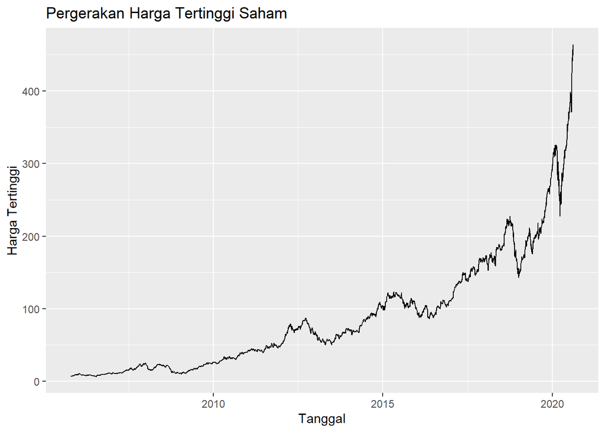

```r
library(ggplot2)

ggplot(data = saham_AS, aes(x = Date, y = High)) +
  geom_line() +
  labs(
    title = "Pergerakan Harga Tertinggi Saham",
    x = "Tanggal",
    y = "Harga Tertinggi")
```

### Area Plot

Untuk menambah estetika dapat dilakukan dengan mengarsir daerah di bawah plot deret waktu. Plot seperti ini disebut **Area Plot**. Hasilnya sebagai berikut.

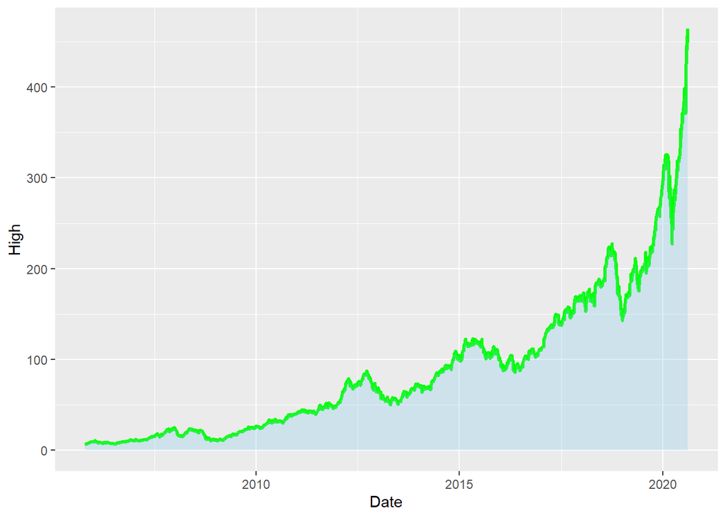

```r
ggplot(data = saham_AS, aes(x=Date,y=High)) +
  geom_line(lwd=1.2, col="green") +
  geom_area(fill="skyblue", alpha=0.3)
```

```r
  labs(x="tanggal", y="Harga Tertinggi")
```

```
## $x
## [1] "tanggal"
##
## $y
## [1] "Harga Tertinggi"
##
## attr(,"class")
## [1] "labels"
```

### Multiple Line Chart

Pada plot ini dapat digunakan untuk membandingkan dan mengidentifikasi tren jangka pendek dan jangka panjang serta memberikan sinyal trading. MA50 merupakan rata-rata pergerakan harga saham selama 50 hari terakhir. Sedangkan MA200 merupakan pergerakan harga jangka panjang (lebih stabil dan menggambarkan tren keseluruhan).

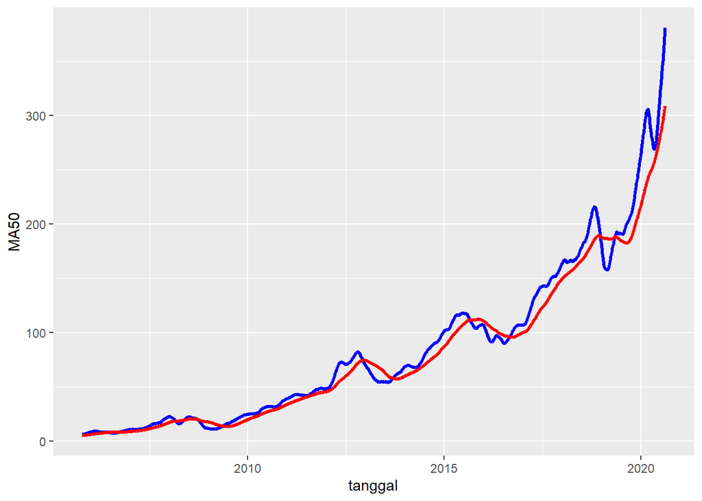

```r
ggplot(data = saham_AS, aes(x=Date)) +
  geom_line(aes(y=MA50), lwd=1.2, col="blue") +
  geom_line(aes(y=MA200), lwd=1.2, col="red") +
  labs(x="tanggal", x="Perkiraan Rata-Rata Pergerakan Harga Saham")
```

Untuk menambahkan nama kelompok digunakan perintah berikut.

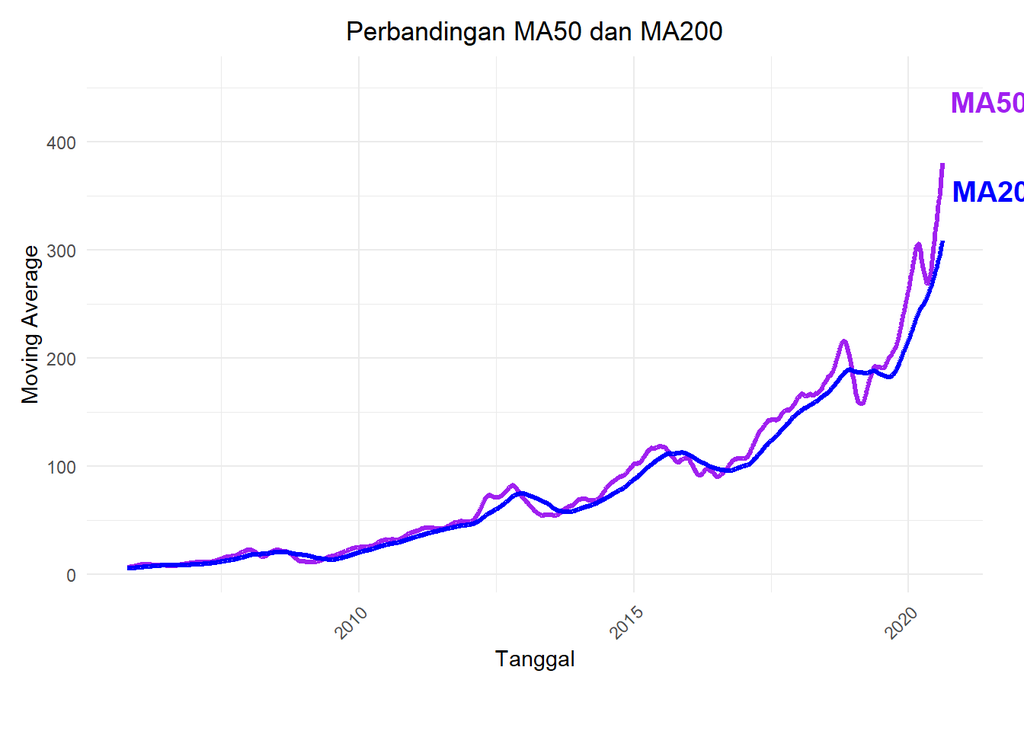

```r
library(ggplot2)

ggplot(data = saham_AS, aes(x = Date)) +
  geom_line(aes(y = MA50), lwd = 1.2, col = "purple") +
  geom_line(aes(y = MA200), lwd = 1.2, col = "blue") +
  labs(
    x = "Tanggal",
    y = "Moving Average",
    title = "Perbandingan MA50 dan MA200"
  ) +
  theme_minimal() +  # Tema lebih bersih
  theme(
    plot.title = element_text(hjust = 0.5),  # Pusatkan judul
    axis.text.x = element_text(angle = 45, hjust = 1),  # Miringkan label sumbu X
    plot.margin = margin(10, 20, 30, 10)  # Tambahkan margin lebih besar
  ) +
  coord_cartesian(clip = "off") +  # Pastikan teks tidak terpotong
  expand_limits(y = max(saham_AS$MA50, saham_AS$MA200) * 1.2) +  # Tambah ruang lebih besar
  annotate("text", x = max(saham_AS$Date), y = max(saham_AS$MA50) * 1.15,
           label = "MA50", color = "purple", size = 5, fontface = "bold", hjust = -0.1) +
  annotate("text", x = max(saham_AS$Date), y = max(saham_AS$MA200) * 1.15,
           label = "MA200", color = "blue", size = 5, fontface = "bold", hjust = -0.1)
```